# Mus chr17 window trees

```r
knitr::opts_chunk$set(echo = TRUE, warning = FALSE, message = FALSE)

#library(ggplot2)
library(tidyverse)
library(cowplot)
library(kableExtra)
library(ggbeeswarm)
library(ggsignif)
library(here)
library("ggtree")
library(eulerr)
source(here("docs", "scripts", "lib", "design.r"))

total_spec = 6

window_size = 10
# Window size in kb

max_tree_rank = 3
```

From the cactus alignment HAL format, we converted to MAF using mm10 as the reference genome (for coordinate system) and then extracted 10kb windows across the scaffold in FASTA format. We then used IQ-tree to infer phylogenies for each window (after some filtering) and examined the frequency and distributions of topologies recovered.

```r
infile = here("data", paste0("mm10-", window_size, "kb-topo-counts-no-pahari.csv"))
all_windows = read.csv(infile, header=T, comment.char="#")
all_windows = all_windows[order(-all_windows$end), ]
all_windows_f = subset(all_windows, filter=="PASS")
# Window trees file

aln_stats_file = here("data", paste0("mm10-", window_size, "kb-window-stats-no-pahari.tsv"))
aln_stats = read.csv(aln_stats_file, header=T, comment.char="#", sep="\t")
aln_stats$window <- gsub('.noanc', '', aln_stats$window)
# Window alignment stats

spec_counts_file = here("data", paste0("mm10-", window_size, "kb-spec-counts-no-pahari.tsv"))
spec_counts = read.csv(spec_counts_file, header=F, sep="\t")
names(spec_counts) = c("spec", "count")
spec_counts = spec_counts %>% filter(spec != "pahari")
# Window spec counts
```

# 1 Alignment filtering

Note the filtering of alignment sites for gappiness precedes these steps. See [Window stats](https://gwct.github.io/mus-t-haplotype/windows.html) for more info.

In addition to the filtering of windows listed below, we could add an additional filter for **alignment length**. For example, we could filter out windows that are shorter than 100bp after removing gappy sites (which would exclude 74 more windows). Here is a distribution of alignment lengths after the gappy site filtering. Let me know if we should try this.

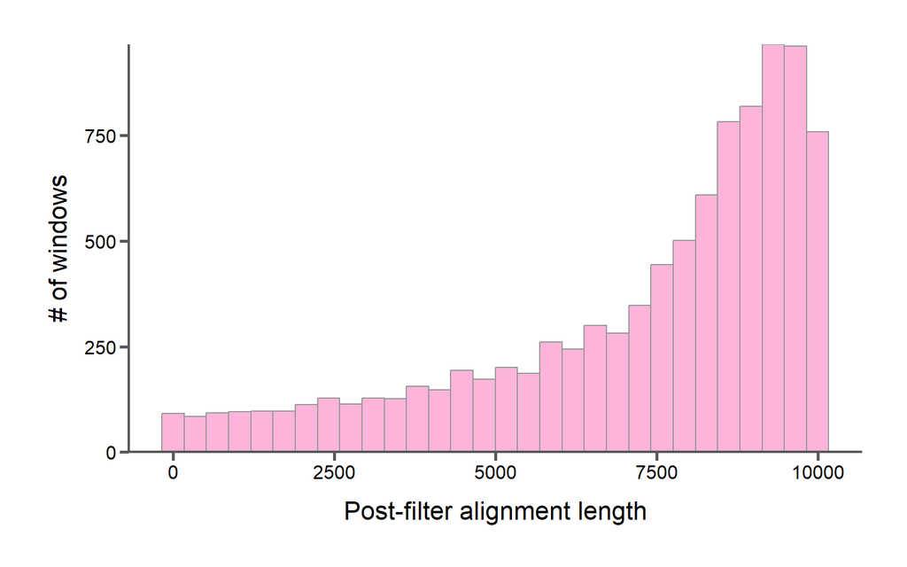

```r
p = ggplot(aln_stats, aes(x=aln.len.filter)) +
  geom_histogram(bins=30, color="#999999", fill=corecol(numcol=1, offset=7)) +
  scale_y_continuous(expand=c(0, 0)) +
  xlab("Post-filter alignment length") +
  ylab("# of windows") +
  bartheme()
print(p)
```

# 2 Window filtering

These filters break down as follows

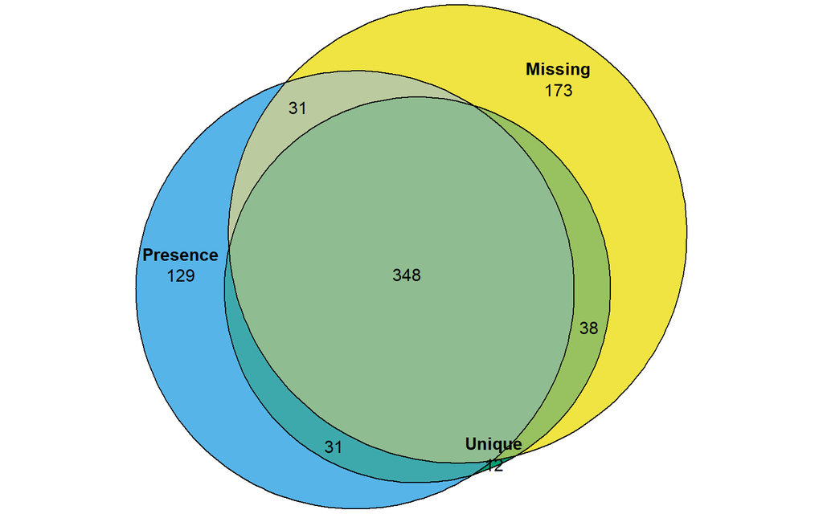

```r
presence = aln_stats %>% filter(total.seqs.filter != 5)
unique_seqs = aln_stats %>% filter(uniq.seqs.filter < 4)
missing = aln_stats %>% filter(seqs.all.missing.gappy.filter != 0)

#filtered_windows = union(union(presence, unique_seqs), missing)$window
#filtered_trees = all_windows %>% filter(filter == "FILTER")
#other = aln_stats %>% filter(total.seqs.filter == 6 & uniq.seqs.filter >= 4 & sites.all.missing.gap != 0 & window %in% filtered_trees$window)

filters = list("Presence" = presence$window,
               "Unique"   = unique_seqs$window,
               "Missing"  = missing$window)

plot(euler(filters), quantities=T, fills=corecol(pal="wilke", numcol=3, offset=1))
```

```r
print(paste0("WINDOWS BEFORE FILTERING: ", nrow(all_windows)))
```

```
## [1] "WINDOWS BEFORE FILTERING: 9499"
```

```r
print(paste0("WINDOWS AFTER  FILTERING: ", nrow(all_windows_f)))
```

```
## [1] "WINDOWS AFTER  FILTERING: 8737"
```

```r
spec_counts$missing = nrow(all_windows) - spec_counts$count
```

## 2.1 Distribution of aligned sequences per window

The “Presence” filter

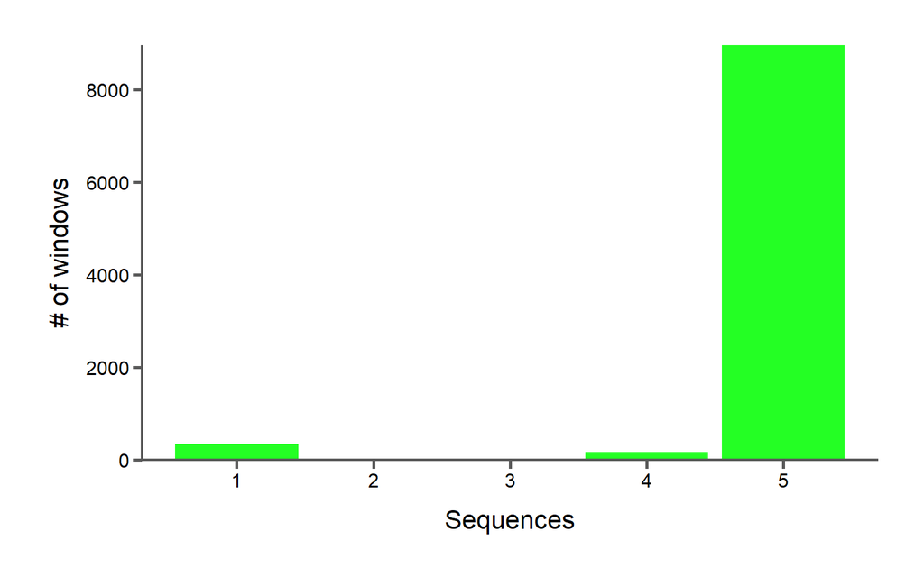

```r
p = ggplot(aln_stats, aes(x=total.seqs.filter)) +
  geom_histogram(stat="count", fill=corecol(numcol=1, offset=6)) +
  scale_x_continuous(breaks=1:6) +
  scale_y_continuous(expand=c(0, 0)) +
  xlab("Sequences") +
  ylab("# of windows") +
  bartheme()
print(p)
```

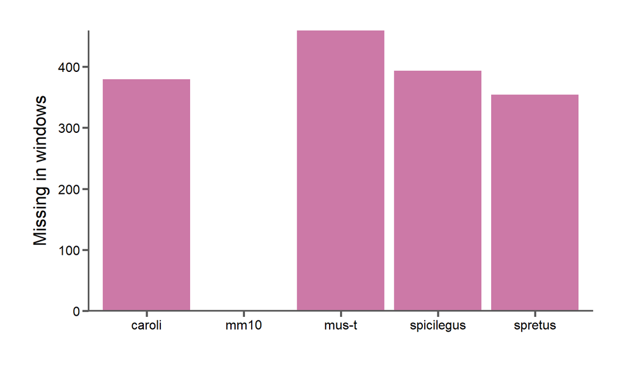

```r
p = ggplot(spec_counts, aes(x=spec, y=missing)) +
  geom_bar(stat="identity", fill=corecol(pal="wilke", numcol=1, offset=6)) +
  #scale_x_continuous(breaks=1:6) +
  scale_y_continuous(expand=c(0, 0)) +
  xlab("") +
  ylab("Missing in windows") +
  bartheme()
print(p)
```

# 3 Distribution of tree topologies

```r
topo_counts = unique(subset(all_windows_f, select=c(topo.num.overall, topo.count.overall, topo.rank.overall, topo.color)))
topo_counts = topo_counts[order(topo_counts$topo.rank.overall),]
num_topos = nrow(topo_counts)
# Get the topology counts

print(paste0("In total ", num_topos, " different topologies were recovered"))
```

```
## [1] "In total 15 different topologies were recovered"
```

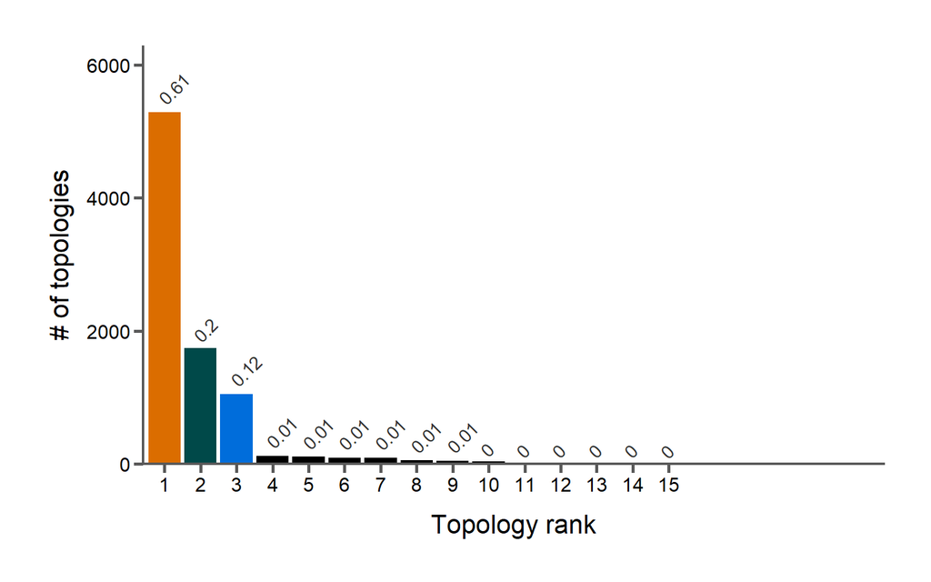

```r
col_rank = 1
for(i in 1:nrow(topo_counts)){
  row = topo_counts[i,]
  cur_col = row$topo.color
  if(cur_col != "#999999"){
    new_label = paste("Top ", col_rank, sep="")
    col_rank = col_rank + 1
  }else{
    new_label = "Other"
  }
  topo_counts$col.cat[topo_counts$topo.num.overall==i] = new_label

  if(row$topo.rank.overall > max_tree_rank){
    topo_counts[i,]$topo.color = "#000000"
  }
}
# Add label and color columns to the topo counts

topo_counts$outline = "transparent"
# Add an outline column -- black outline is chrome topo

topo_counts$topo.prop = round(topo_counts$topo.count / sum(topo_counts$topo.count), 2)
# Percentage for each topology.

topo_counts_top = subset(topo_counts, topo.rank.overall <= 20)

bar_fills = as.character(topo_counts_top$topo.color)
names(bar_fills) = topo_counts_top$topo.rank.overall

fig_2a = ggplot(topo_counts_top, aes(x=reorder(topo.rank.overall, -topo.count.overall), y=topo.count.overall, fill=as.character(topo.rank.overall), color=outline, label=topo.prop)) +
  geom_bar(stat="identity", size=2) +
  geom_text(position=position_dodge(width=0.9), size=4, color="#333333", hjust=-0.15, vjust=-0.25, angle=45) +
  expand_limits(x = c(1,21)) +
  scale_y_continuous(expand=c(0, 0), limits=c(0,max(topo_counts$topo.count.overall)+1000)) +
  scale_fill_manual(name="", values=bar_fills) +
  scale_color_manual(name="", limits=topo_counts$outline, values=topo_counts$outline) +
  xlab("Topology rank") +
  ylab("# of topologies") +
  bartheme() +
  theme(legend.position="none")
print(fig_2a)
```

# 4 Most frequent topologies

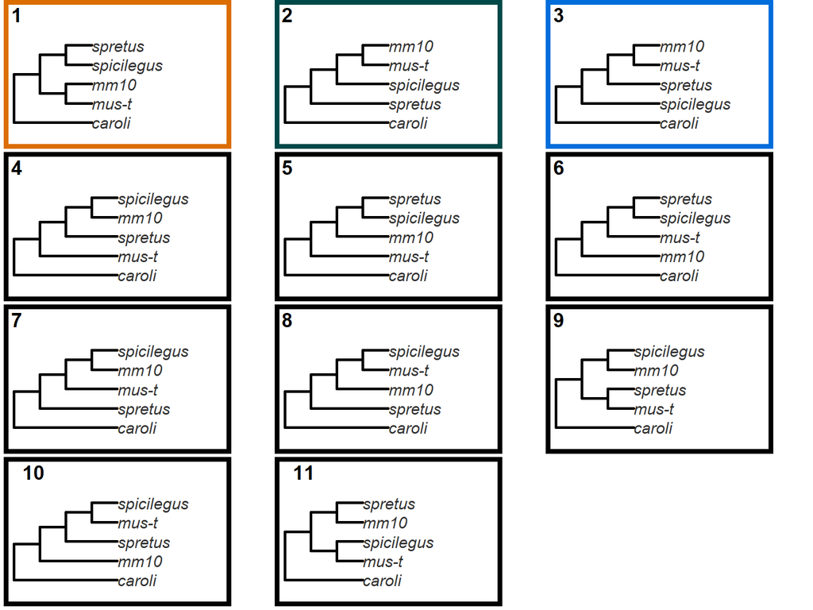

```r
top_topos = head(as.numeric(topo_counts$topo.rank.overall),11)
#top_topos = 1:11
# Get the top ranking topologies for this chrome

tree_figs = list()
# A list to hold the three tree figs in

for(j in 1:length(top_topos)){
  # Generate figures for each of the top 3 topos
  cur_topo = top_topos[j]
  cur_tree_raw = as.character(all_windows_f[all_windows_f$topo.rank.overall==cur_topo,]$topo[1])

  # cur_tree_raw = gsub("rdil", "R. dilectus", cur_tree_raw)
  # cur_tree_raw = gsub("gdol", "G. dolicurus", cur_tree_raw)
  # cur_tree_raw = gsub("mm10", "M. musculus", cur_tree_raw)
  # cur_tree_raw = gsub("pdel", "P. delectorum", cur_tree_raw)
  # cur_tree_raw = gsub("mnat", "M. natalensis", cur_tree_raw)
  # cur_tree_raw = gsub("hall", "H. alleni", cur_tree_raw)
  # cur_tree_raw = gsub("rsor", "R. soricoides", cur_tree_raw)

  cur_tree = read.tree(text=cur_tree_raw)
  #cur_color_cat = topo_counts$col.cat[topo_counts$topo.rank.overall==cur_topo]
  #cur_color_ind = which(cur_color_cat == bar_labels)
  cur_color = as.character(topo_counts$topo.color[topo_counts$topo.rank.overall==cur_topo])
  # Get all info for the current topo (color, string, etc.)

  #nodecheck(cur_tree, tree_type="object", xmax=10)

  cur_fig = ggtree(cur_tree, size=1, ladderize=T) +
    xlim_tree(7) +
    ggplot2::ylim(0, 7) +
    ggplot2::xlim(0, 8) +
    geom_tiplab(color="#333333", fontface='italic', size=4) +
    theme(plot.margin = unit(c(0,1,0,0), "cm")) +
    #theme_tree2() +
    theme(panel.border=element_rect(color=cur_color, fill="NA", size=3))
  #print(cur_fig)
  # Generate the tree

  tree_figs[[j]] = cur_fig
  # Save the tree fig in th elist
}

fig_2b = plot_grid(plotlist=tree_figs, nrow=4, ncol=3, labels=1:11, label_size=14, hjust=-1, align="vh")
print(fig_2b)
```

# 5 Chromoplot

The distribution of topologies (and filtered windows in grey) across the chromosome

```r
chrome_to_plot = "17"
chrome_str = paste("chr", chrome_to_plot, sep="")
chrdata = subset(all_windows, chr==chrome_str)
total_windows = length(chrdata[,1])
chrdata_f = subset(all_windows_f, chr==chrome_str)
used_windows = length(chrdata_f[,1])
num_topos = max(chrdata_f$topo.num.chrome)

chr_len = chrdata[chrdata$chr==chrome_str, ]$chr.len[1]

chrdata$col.cat = NA
chrdata$ystart = NA
chrdata$yend = NA
cur_col = "#999999"
topo_counts$topo.color = as.character(topo_counts$topo.color)
for(i in 1:nrow(chrdata)) {
  cur_topo_num = chrdata[i,]$topo.num.overall
  if(aln_stats[aln_stats$window == chrdata[i,]$window,]$total.seqs.filter != 5){
    cur_col = "#999999"
    chrdata[i,]$ystart = 0
    chrdata[i,]$yend = 4
  }else if(is.na(cur_topo_num)){
    cur_col = "#ffffff"
    chrdata[i,]$ystart = 0
    chrdata[i,]$yend = 4
  }else{
    cur_col = topo_counts$topo.color[topo_counts$topo.num.overall==cur_topo_num]
    #print(cur_col)
  }
  chrdata[i,]$col.cat = cur_col
}

chrdata$ystart[chrdata$topo.rank.overall==1] = 4
chrdata$yend[chrdata$topo.rank.overall==1] = 3

chrdata$ystart[chrdata$topo.rank.overall==2] = 3
chrdata$yend[chrdata$topo.rank.overall==2] = 2

chrdata$ystart[chrdata$topo.rank.overall==3] = 2
chrdata$yend[chrdata$topo.rank.overall==3] = 1

chrdata$ystart[chrdata$topo.rank.overall>3] = 1
chrdata$yend[chrdata$topo.rank.overall>3] = 0
#chrdata$col.cat[chrdata$topo.rank.chrome>3] = "#999999"

cols_labs = levels(as.factor(chrdata$col.cat))
names(cols_labs) = levels(as.factor(chrdata$col.cat))

chr_breaks_5mb = seq(0,chr_len,by=5000000)
chr_labels_5mb = c()
first = TRUE
label_num = 1
for(i in chr_breaks_5mb){
  if(first){
    first = FALSE
    chr_labels_5mb = c(chr_labels_5mb, "")
    next
  }

  #label_str = paste0(label_num * 5, "Mb")
  chr_labels_5mb = c(chr_labels_5mb, label_num * 5)
  label_num = label_num + 1
}
```

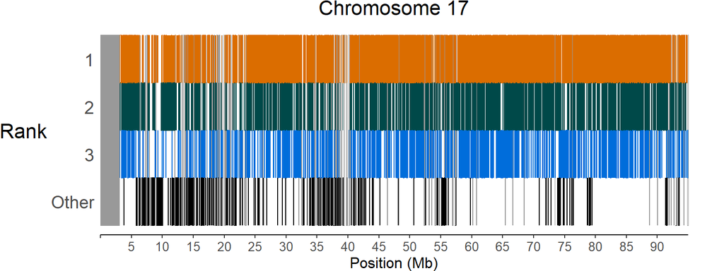

```r
fig_2c = ggplot(chrdata, aes(x=start, y=ystart, color=col.cat)) +
  geom_rect(aes(ymin=ystart, ymax=yend, xmin=start,xmax=end)) +
  #geom_segment(aes(x=start, y=ystart, xend=start, yend=yend)) +
  scale_color_manual(values=cols_labs) +
  scale_y_continuous(limits=c(0,4), breaks=0.5:3.5, labels=c("Other", "3", "2", "1")) +
  scale_x_continuous(limits=c(0,chr_len), breaks=chr_breaks_5mb, labels=chr_labels_5mb, expand=c(0,0)) +
  # geom_hline(yintercept=2,color="black") +
  ylab("Rank") +
  xlab("Position (Mb)") +
  ggtitle("Chromosome 17") +
  theme_classic() +
  theme(axis.title.x=element_text(size=12),
        axis.text.x = element_text(size=10),#, angle=25, vjust=1, hjust=1),
        axis.text.y=element_text(size=14),
        axis.title.y=element_text(size=16, angle=0, vjust=0.5),
        axis.line.y=element_blank(),
        axis.ticks.y=element_blank(),
        legend.position="none",
        legend.key.width = unit(0.75,  unit = "cm"),
        legend.spacing.x = unit(0.25, 'cm'),
        legend.title = element_blank(),
        legend.text=element_text(size=12),
        plot.title = element_text(hjust=0.5, size=16),
        plot.margin = unit(c(0,1,0,0), "cm")
  )
print(fig_2c)
```

# 6 Topology frequencies in inversions

We counted the frequency of topologies 0f 10kb windows within inversions to see if they differ from overall or from windows not within inversions

These are the (0-based) coordinates of the inversions, as well as IDs I’ve assigned them.

```r
inversions_file = here("data", "inversions.bed")
inversions = read_tsv(inversions_file, col_names=c("chr", "start", "end", "id"))

inversions %>%
  kable() %>%
  kable_styling(bootstrap_options=c("striped", "condended", "responsive"), full_width=F, position="center", fixed_thead=T)
```

| chr | start | end | id |
| --- | --- | --- | --- |
| chr17 | 5747330 | 6957919 | inv01 |
| chr17 | 7435307 | 13016510 | inv02 |
| chr17 | 14068228 | 18051507 | inv03 |
| chr17 | 19400999 | 40049964 | inv04 |

Topology 2 is more common in inversions 1 and 2:

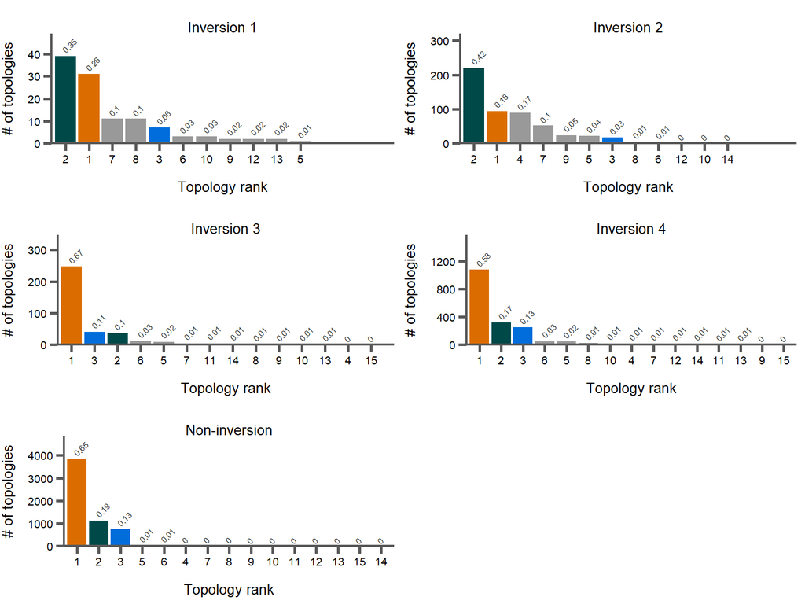

```r
topoPlots <- function(windows_df, df_label, y_adj){

  topo_counts = windows_df %>%
    select(topo.num.overall, topo.rank.overall, topo.color) %>%
    group_by(topo.num.overall, topo.color, topo.rank.overall) %>%
    summarize(topo.count=n())

  topo_counts$topo.prop = round(topo_counts$topo.count / sum(topo_counts$topo.count), 2)
  num_topos = nrow(topo_counts)
  # Get the topology counts

  topo_counts$outline = "transparent"

  bar_fills = as.character(topo_counts$topo.color)
  names(bar_fills) = topo_counts$topo.rank.overall

  topo_dist = ggplot(topo_counts, aes(x=reorder(topo.rank.overall, -topo.count), y=topo.count, fill=as.character(topo.rank.overall), color=outline, label=topo.prop)) +
    geom_bar(stat="identity", size=2) +
    geom_text(position=position_dodge(width=0.9), size=2, color="#333333", hjust=-0.15, vjust=-0.25, angle=45) +
    expand_limits(x = c(1,15)) +
    scale_y_continuous(expand=c(0, 0), limits=c(0,max(topo_counts$topo.count)+y_adj)) +
    scale_fill_manual(name="", values=bar_fills) +
    scale_color_manual(name="", limits=topo_counts$outline, values=topo_counts$outline) +
    ggtitle(df_label) +
    xlab("Topology rank") +
    ylab("# of topologies") +
    bartheme() +
    theme(legend.position="none",
          plot.title = element_text(hjust=0.5, size=10),
          axis.text=element_text(size=8),
          axis.title=element_text(size=10),
          plot.margin = unit(c(0.5,0.2,0.2,0), "cm"))
  #print(topo_dist)

  return(list("topo.counts"=topo_counts,
              "topo.plot"=topo_dist,
              "num.topos"=num_topos))

}
# This function wraps the counting and plotting code from above so it can be called for each inversion

####################

# grep -v "^#" mm10-10kb-topo-counts-no-pahari.csv | grep -v "window,chr" | awk 'BEGIN{FS=","; OFS="\t"} {print $2,$4,$5,$1}' | sed 's/\"//g' > mm10-10kb-windows.bed
# bedtools intersect -wao -a mm10-10kb-windows.bed -b inversions.bed > mm10-10kb-windows-inversions.intersect
# First, outside of R, use bedtools to get the intersect between the 10kb windows and the inversions

intersects_file = here("data", "mm10-10kb-windows-inversions.intersect")
intersects = read_tsv(intersects_file, col_names=c("chr", "start", "end", "window", "inv.chr", "inv.start", "inv.end", "inv.overlap", "inv.overlap.bp"))
# Read the windows with inversion intersects labeled

intersects = intersects %>% select(window, inv.overlap, inv.overlap.bp)
# Subset the inversion intersects df to only the window id and the inversion id

all_windows_f_overlaps = left_join(all_windows_f, intersects, by="window")
# Join the intersects and the main windows df

inv1 = topoPlots(subset(all_windows_f_overlaps, inv.overlap == "inv01"), "Inversion 1", 10)
inv2 = topoPlots(subset(all_windows_f_overlaps, inv.overlap == "inv02"), "Inversion 2", 100)
inv3 = topoPlots(subset(all_windows_f_overlaps, inv.overlap == "inv03"), "Inversion 3", 100)
inv4 = topoPlots(subset(all_windows_f_overlaps, inv.overlap == "inv04"), "Inversion 4", 500)
non_inv = topoPlots(subset(all_windows_f_overlaps, inv.overlap == "."), "Non-inversion", 1000)
# Count topologies for each inversion as well as non-inversion windows

p = plot_grid(inv1$topo.plot, inv2$topo.plot, inv3$topo.plot, inv4$topo.plot, non_inv$topo.plot, nrow=3, ncol=2)
print(p)
```

```r
# Combine the plots and render
```

# 7 Tree similarity in windows around inversion breakpoints

We measured tree similarity with Robinson-Foulds and weighted Robinson-Foulds distances between the 10kb windows overlapping each inversion breakpoint and each 10kb window 5Mb up and downstream of them. We also randomly sampled pairs windows across the chromosome for comparison.

```r
inv_bp_dists_file = here("data", "coord-query", "inv-bps-5-Mb.bed.chr17.dists")
inv_bp_dists = read_csv(inv_bp_dists_file)
inv_bp_dists$label = "Inversion breakpoints"

rand_dists_file = here("data", "coord-query", "inv-bps-5-Mb.bed.chr17.random")
rand_dists = read_csv(rand_dists_file)
rand_dists$label = "Random windows"
```

## 7.1 All breakpoints

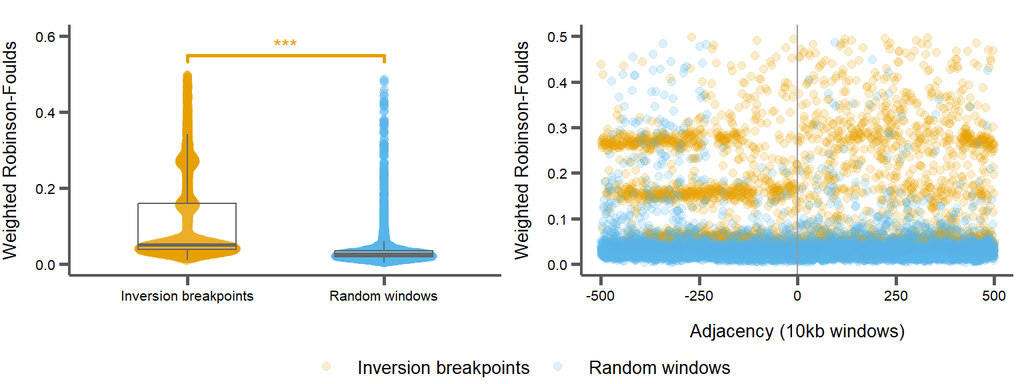

```r
plotBPDists <- function(dists, bp_only=T, yvar="wrf", yfilt=0.5, color_pal="windows"){

  x_comps = list(c("Inversion breakpoints", "Random windows"))
  # For significance testing

  if(yfilt){
    dists = dists %>% filter(.[[yvar]] <= yfilt)
  }
  # Filter the y-variable if specified

  if(color_pal == "windows"){
    cols = corecol(pal="wilke", numcol=2)
  }else if(color_pal == "st"){
    cols = rev(c(corecol(pal="wilke", numcol=2, offset=1)))
  }

  ##########

  wrf_dist = dists %>%
  ggplot(aes_string(x="label", y=yvar, color="label")) +
  geom_quasirandom(size=2, width=0.25, alpha=0.30) +
  geom_boxplot(outlier.shape=NA, alpha=0.15, width=0.5, color="#666666") +
  geom_signif(comparisons=x_comps, map_signif_level=TRUE, textsize=4, size=1, step_increase=0.12, margin_top=0.1, test="ks.test") +
  scale_y_continuous(limits=c(0,0.6)) +
  xlab("") +
  ylab("Weighted Robinson-Foulds") +
  scale_color_manual(values=cols) +
  bartheme() +
  theme(legend.position="none",
        #axis.text.x=element_text(angle=15, hjust=1),
        axis.text=element_text(size=8),
        axis.title=element_text(size=10),
        plot.margin = unit(c(0.5,0.2,0.2,0), "cm"))
  # Boxplot

  ##########

  if(bp_only){
    dists = dists %>% filter(label == "Inversion breakpoints")
  }
  # Only display the inversion bps on the scatter plot if specified

  wrf_adj = dists %>%
  ggplot(aes_string(x="adj", y=yvar, color="label")) +
  geom_point(size=2, alpha=0.20) +
  geom_vline(xintercept=0, color="#999999") +
  scale_x_continuous(limits=c(-500,500)) +
  scale_y_continuous(limits=c(0,0.5)) +
  xlab("Adjacency (10kb windows)") +
  ylab("Weighted Robinson-Foulds") +
  scale_color_manual(values=cols) +
  bartheme() +
  theme(legend.position="bottom",
        legend.text=element_text(size=10),
        axis.text=element_text(size=8),
        axis.title=element_text(size=10),
        plot.margin = unit(c(0.5,0.2,0.2,0), "cm"))
  # Scatter plot

  ##########

  return(list("wrf.dist"=wrf_dist,
              "wrf.adj"=wrf_adj))
}

####################

all_dists = rbind(inv_bp_dists, rand_dists)
inv_bp_plots = plotBPDists(all_dists, bp_only=F)

leg = get_legend(inv_bp_plots$wrf.adj)

p_main = plot_grid(inv_bp_plots$wrf.dist, inv_bp_plots$wrf.adj + theme(legend.position="none"), ncol=2)
p = plot_grid(p_main, leg, nrow=2, rel_heights=c(1,0.1))
print(p)
```

## 7.2 Inversion 1 breakpoints

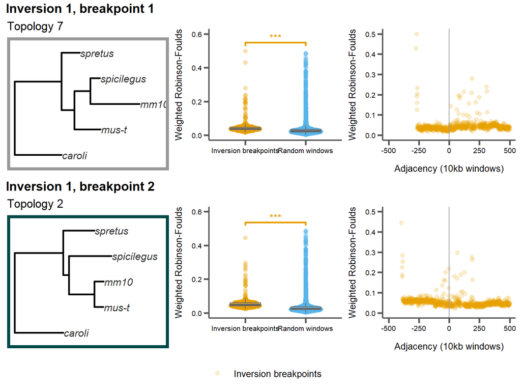

```r
plotBPTree <- function(df_row, xmax){
  cur_tree = read.tree(text=df_row$unparsed.tree)
  cur_color = df_row$topo.color
  cur_rank = df_row$topo.rank.overall

  cur_tree_p = ggtree(cur_tree, size=1, ladderize=2) +
    xlim_tree(xmax) +
    geom_tiplab(color="#333333", fontface='italic', size=4) +
    #theme(plot.margin = unit(c(0,1,0,0), "cm")) +
    ggtitle(paste0("Topology ", cur_rank)) +
    theme(panel.border=element_rect(color=cur_color, fill="NA", size=3))

  return(cur_tree_p)
}

####################

inv_bp_windows = all_windows_f_overlaps %>% filter(inv.overlap == "inv01", inv.overlap.bp < 10000)
tree1 = plotBPTree(inv_bp_windows[1,], 0.06)
tree2 = plotBPTree(inv_bp_windows[2,], 0.06)
# Get the trees around both breakpoints

##########

inv_bp1_dists = inv_bp_dists %>% filter(bed.id == "inv01.bp01")
dists1 = rbind(inv_bp1_dists, rand_dists)
inv_bp1_plots = plotBPDists(dists1)
# Get the distances and plots from bp1

inv_bp2_dists = inv_bp_dists %>% filter(bed.id == "inv01.bp02")
dists2 = rbind(inv_bp2_dists, rand_dists)
inv_bp2_plots = plotBPDists(dists2)
# Get the distances and plots from bp2

#print(wrf_adj)

##########

leg = get_legend(inv_bp1_plots$wrf.adj)
title1 = ggdraw() +
  draw_label("Inversion 1, breakpoint 1",
             fontface="bold",
             x=0,
             hjust=0) +
  theme(plot.margin=margin(0,0,0,7))

title2 = ggdraw() +
  draw_label("Inversion 1, breakpoint 2",
             fontface="bold",
             x=0,
             hjust=0) +
  theme(plot.margin=margin(0,0,0,7))

p1_main = plot_grid(tree1, inv_bp1_plots$wrf.dist, inv_bp1_plots$wrf.adj + theme(legend.position="none"), ncol=3)
p1 = plot_grid(title1, p1_main, nrow=2, rel_heights=c(0.1,1))

p2_main = plot_grid(tree2, inv_bp2_plots$wrf.dist, inv_bp2_plots$wrf.adj + theme(legend.position="none"), ncol=3)
p2 = plot_grid(title2, p2_main, nrow=2, rel_heights=c(0.1,1))

p_main = plot_grid(p1, p2, nrow=2, label_size=14, align='vh')
p = plot_grid(p_main, leg, nrow=2, rel_heights=c(1,0.1))
print(p)
```

## 7.3 Inversion 2 breakpoints

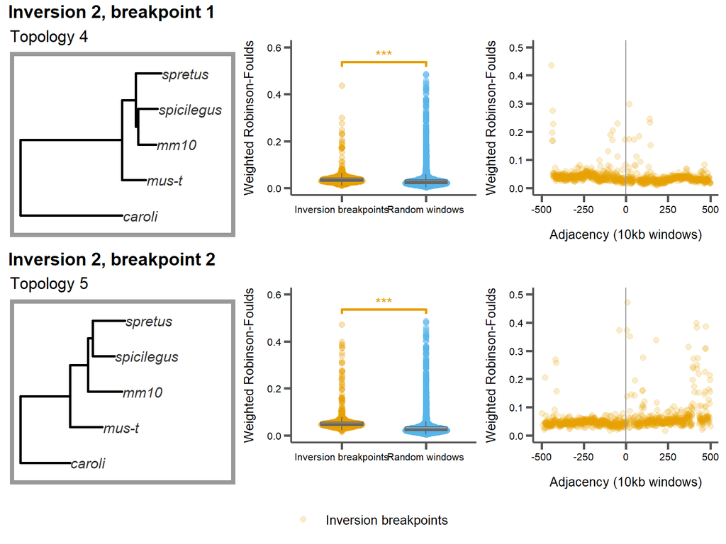

```r
inv_bp_windows = all_windows_f_overlaps %>% filter(inv.overlap == "inv02", inv.overlap.bp < 10000)
tree1 = plotBPTree(inv_bp_windows[1,], 0.06)
tree2 = plotBPTree(inv_bp_windows[2,], 0.06)
# Get the trees around both breakpoints

##########

inv_bp1_dists = inv_bp_dists %>% filter(bed.id == "inv02.bp01")
dists1 = rbind(inv_bp1_dists, rand_dists)
inv_bp1_plots = plotBPDists(dists1)
# Get the distances and plots from bp1

inv_bp2_dists = inv_bp_dists %>% filter(bed.id == "inv02.bp02")
dists2 = rbind(inv_bp2_dists, rand_dists)
inv_bp2_plots = plotBPDists(dists2)
# Get the distances and plots from bp2

#print(wrf_adj)

##########

leg = get_legend(inv_bp1_plots$wrf.adj)
title1 = ggdraw() +
  draw_label("Inversion 2, breakpoint 1",
             fontface="bold",
             x=0,
             hjust=0) +
  theme(plot.margin=margin(0,0,0,7))

title2 = ggdraw() +
  draw_label("Inversion 2, breakpoint 2",
             fontface="bold",
             x=0,
             hjust=0) +
  theme(plot.margin=margin(0,0,0,7))

p1_main = plot_grid(tree1, inv_bp1_plots$wrf.dist, inv_bp1_plots$wrf.adj + theme(legend.position="none"), ncol=3)
p1 = plot_grid(title1, p1_main, nrow=2, rel_heights=c(0.1,1))

p2_main = plot_grid(tree2, inv_bp2_plots$wrf.dist, inv_bp2_plots$wrf.adj + theme(legend.position="none"), ncol=3)
p2 = plot_grid(title2, p2_main, nrow=2, rel_heights=c(0.1,1))

p_main = plot_grid(p1, p2, nrow=2, label_size=14, align='vh')
p = plot_grid(p_main, leg, nrow=2, rel_heights=c(1,0.1))
print(p)
```

## 7.4 Inversion 3 breakpoints

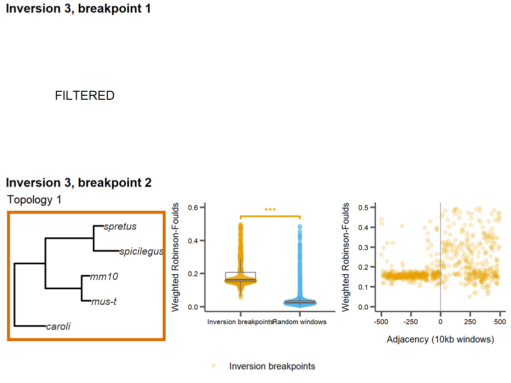

```r
inv_bp_windows = all_windows_f_overlaps %>% filter(inv.overlap == "inv03", inv.overlap.bp < 10000)
tree1 = ggdraw() + draw_label("FILTERED")
tree2 = plotBPTree(inv_bp_windows[1,], 0.16)
# Get the trees around both breakpoints

##########

inv_bp1_dists = inv_bp_dists %>% filter(bed.id == "inv03.bp01")
dists1 = rbind(inv_bp1_dists, rand_dists)
inv_bp1_plots = plotBPDists(dists1)
# Get the distances and plots from bp1

inv_bp2_dists = inv_bp_dists %>% filter(bed.id == "inv03.bp02")
dists2 = rbind(inv_bp2_dists, rand_dists)
inv_bp2_plots = plotBPDists(dists2)
# Get the distances and plots from bp2

#print(wrf_adj)

##########

leg = get_legend(inv_bp2_plots$wrf.adj)
title1 = ggdraw() +
  draw_label("Inversion 3, breakpoint 1",
             fontface="bold",
             x=0,
             hjust=0) +
  theme(plot.margin=margin(0,0,0,7))

title2 = ggdraw() +
  draw_label("Inversion 3, breakpoint 2",
             fontface="bold",
             x=0,
             hjust=0) +
  theme(plot.margin=margin(0,0,0,7))

p1_main = plot_grid(tree1, NULL, NULL, ncol=3)
p1 = plot_grid(title1, p1_main, nrow=2, rel_heights=c(0.1,1))

p2_main = plot_grid(tree2, inv_bp2_plots$wrf.dist, inv_bp2_plots$wrf.adj + theme(legend.position="none"), ncol=3)
p2 = plot_grid(title2, p2_main, nrow=2, rel_heights=c(0.1,1))

p_main = plot_grid(p1, p2, nrow=2, label_size=14, align='vh')
p = plot_grid(p_main, leg, nrow=2, rel_heights=c(1,0.1))
print(p)
```

## 7.5 Inversion 4 breakpoints

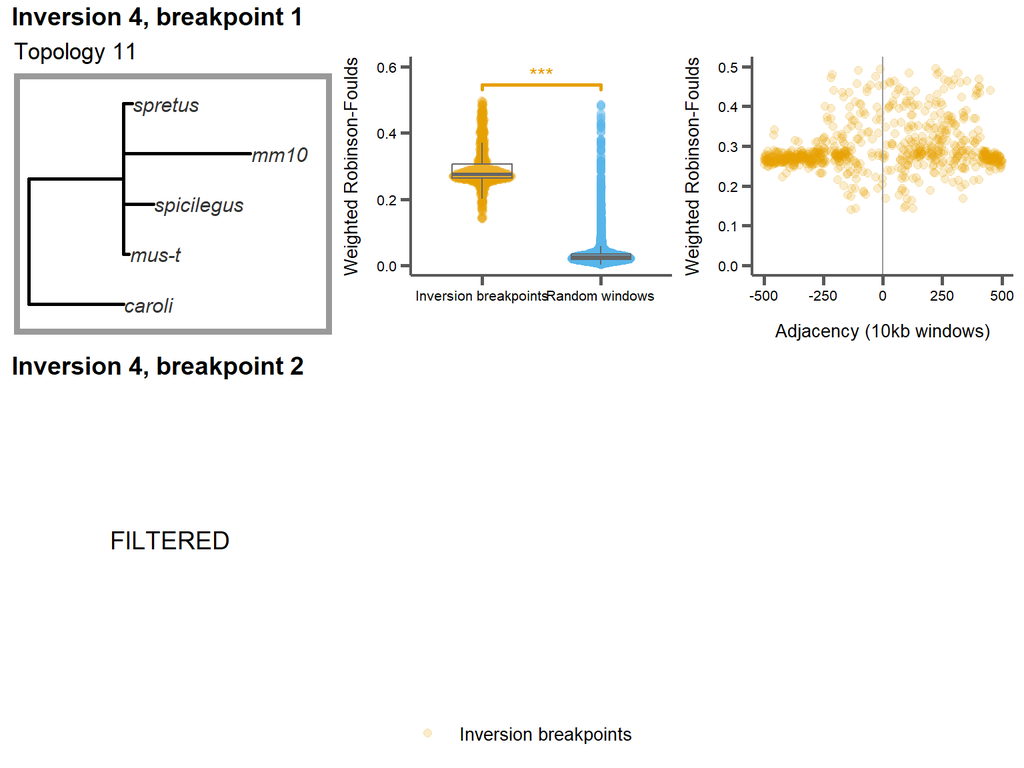

```r
inv_bp_windows = all_windows_f_overlaps %>% filter(inv.overlap == "inv04", inv.overlap.bp < 10000)
tree1 = plotBPTree(inv_bp_windows[1,], 0.25)
tree2 = ggdraw() + draw_label("FILTERED")
# Get the trees around both breakpoints

##########

inv_bp1_dists = inv_bp_dists %>% filter(bed.id == "inv04.bp01")
dists1 = rbind(inv_bp1_dists, rand_dists)
inv_bp1_plots = plotBPDists(dists1)
# Get the distances and plots from bp1

inv_bp2_dists = inv_bp_dists %>% filter(bed.id == "inv04.bp02")
dists2 = rbind(inv_bp2_dists, rand_dists)
inv_bp2_plots = plotBPDists(dists2)
# Get the distances and plots from bp2

#print(wrf_adj)

##########

leg = get_legend(inv_bp1_plots$wrf.adj)
title1 = ggdraw() +
  draw_label("Inversion 4, breakpoint 1",
             fontface="bold",
             x=0,
             hjust=0) +
  theme(plot.margin=margin(0,0,0,7))

title2 = ggdraw() +
  draw_label("Inversion 4, breakpoint 2",
             fontface="bold",
             x=0,
             hjust=0) +
  theme(plot.margin=margin(0,0,0,7))

p1_main = plot_grid(tree1, inv_bp1_plots$wrf.dist, inv_bp1_plots$wrf.adj + theme(legend.position="none"), ncol=3)
p1 = plot_grid(title1, p1_main, nrow=2, rel_heights=c(0.1,1))

p2_main = plot_grid(tree2, NULL, NULL, ncol=3)
p2 = plot_grid(title2, p2_main, nrow=2, rel_heights=c(0.1,1))

p_main = plot_grid(p1, p2, nrow=2, label_size=14, align='vh')
p = plot_grid(p_main, leg, nrow=2, rel_heights=c(1,0.1))
print(p)
```

# 8 Tree similarity around breakpoints to the species tree

## 8.1 All breakpoints

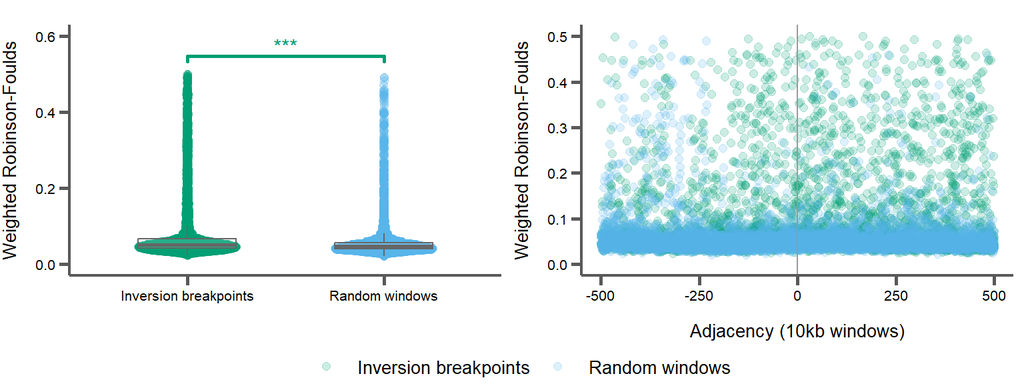

```r
inv_bp_plots = plotBPDists(all_dists, bp_only=F, yvar="wrf.st", color_pal="st")

leg = get_legend(inv_bp_plots$wrf.adj)

p_main = plot_grid(inv_bp_plots$wrf.dist, inv_bp_plots$wrf.adj + theme(legend.position="none"), ncol=2)
p = plot_grid(p_main, leg, nrow=2, rel_heights=c(1,0.1))
print(p)
```

## 8.2 Inversion 1 breakpoints

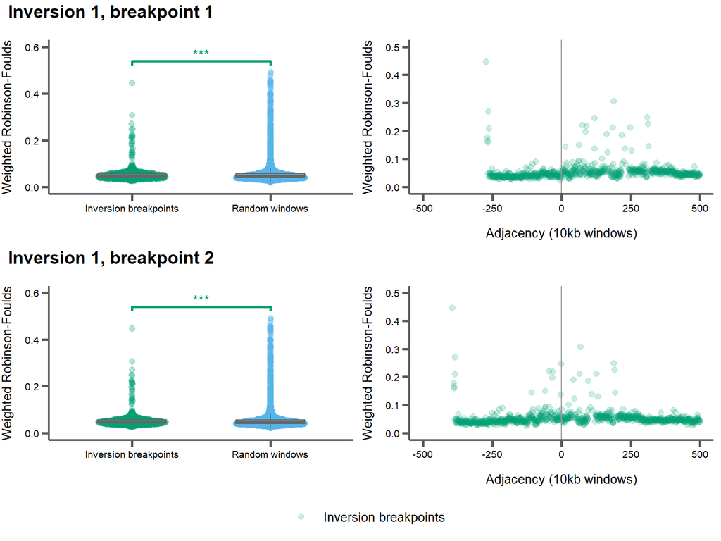

```r
inv_bp_windows = all_windows_f_overlaps %>% filter(inv.overlap == "inv01", inv.overlap.bp < 10000)
#tree1 = plotBPTree(inv_bp_windows[1,], 0.06)
#tree2 = plotBPTree(inv_bp_windows[2,], 0.06)
# Get the trees around both breakpoints

##########

inv_bp1_dists = inv_bp_dists %>% filter(bed.id == "inv01.bp01")
dists1 = rbind(inv_bp1_dists, rand_dists)
inv_bp1_plots = plotBPDists(dists1, yvar="wrf.st", color_pal="st")
# Get the distances and plots from bp1

inv_bp2_dists = inv_bp_dists %>% filter(bed.id == "inv01.bp02")
dists2 = rbind(inv_bp2_dists, rand_dists)
inv_bp2_plots = plotBPDists(dists2, yvar="wrf.st", color_pal="st")
# Get the distances and plots from bp2

#print(wrf_adj)

##########

leg = get_legend(inv_bp1_plots$wrf.adj)
title1 = ggdraw() +
  draw_label("Inversion 1, breakpoint 1",
             fontface="bold",
             x=0,
             hjust=0) +
  theme(plot.margin=margin(0,0,0,7))

title2 = ggdraw() +
  draw_label("Inversion 1, breakpoint 2",
             fontface="bold",
             x=0,
             hjust=0) +
  theme(plot.margin=margin(0,0,0,7))

p1_main = plot_grid(inv_bp1_plots$wrf.dist, inv_bp1_plots$wrf.adj + theme(legend.position="none"), ncol=2)
p1 = plot_grid(title1, p1_main, nrow=2, rel_heights=c(0.1,1))

p2_main = plot_grid(inv_bp2_plots$wrf.dist, inv_bp2_plots$wrf.adj + theme(legend.position="none"), ncol=2)
p2 = plot_grid(title2, p2_main, nrow=2, rel_heights=c(0.1,1))

p_main = plot_grid(p1, p2, nrow=2, label_size=14, align='vh')
p = plot_grid(p_main, leg, nrow=2, rel_heights=c(1,0.1))
print(p)
```

## 8.3 Inversion 2 breakpoints

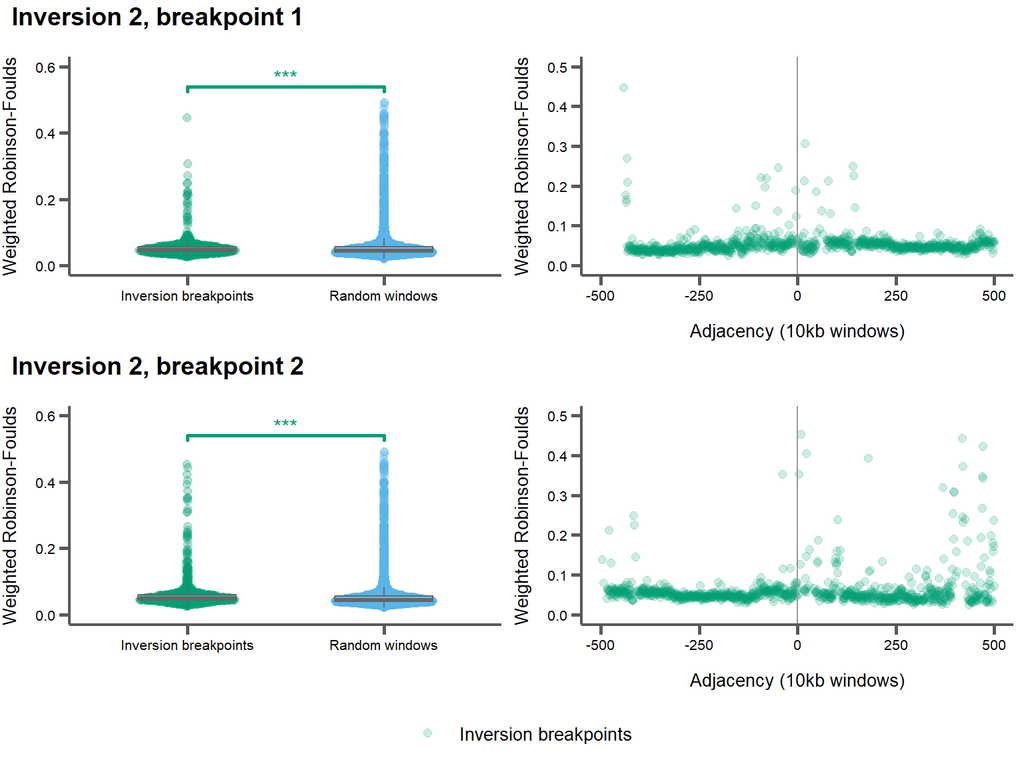

```r
inv_bp_windows = all_windows_f_overlaps %>% filter(inv.overlap == "inv02", inv.overlap.bp < 10000)
#tree1 = plotBPTree(inv_bp_windows[1,], 0.06)
#tree2 = plotBPTree(inv_bp_windows[2,], 0.06)
# Get the trees around both breakpoints

##########

inv_bp1_dists = inv_bp_dists %>% filter(bed.id == "inv02.bp01")
dists1 = rbind(inv_bp1_dists, rand_dists)
inv_bp1_plots = plotBPDists(dists1, yvar="wrf.st", color_pal="st")
# Get the distances and plots from bp1

inv_bp2_dists = inv_bp_dists %>% filter(bed.id == "inv02.bp02")
dists2 = rbind(inv_bp2_dists, rand_dists)
inv_bp2_plots = plotBPDists(dists2, yvar="wrf.st", color_pal="st")
# Get the distances and plots from bp2

#print(wrf_adj)

##########

leg = get_legend(inv_bp1_plots$wrf.adj)
title1 = ggdraw() +
  draw_label("Inversion 2, breakpoint 1",
             fontface="bold",
             x=0,
             hjust=0) +
  theme(plot.margin=margin(0,0,0,7))

title2 = ggdraw() +
  draw_label("Inversion 2, breakpoint 2",
             fontface="bold",
             x=0,
             hjust=0) +
  theme(plot.margin=margin(0,0,0,7))

p1_main = plot_grid(inv_bp1_plots$wrf.dist, inv_bp1_plots$wrf.adj + theme(legend.position="none"), ncol=2)
p1 = plot_grid(title1, p1_main, nrow=2, rel_heights=c(0.1,1))

p2_main = plot_grid(inv_bp2_plots$wrf.dist, inv_bp2_plots$wrf.adj + theme(legend.position="none"), ncol=2)
p2 = plot_grid(title2, p2_main, nrow=2, rel_heights=c(0.1,1))

p_main = plot_grid(p1, p2, nrow=2, label_size=14, align='vh')
p = plot_grid(p_main, leg, nrow=2, rel_heights=c(1,0.1))
print(p)
```

## 8.4 Inversion 3 breakpoints

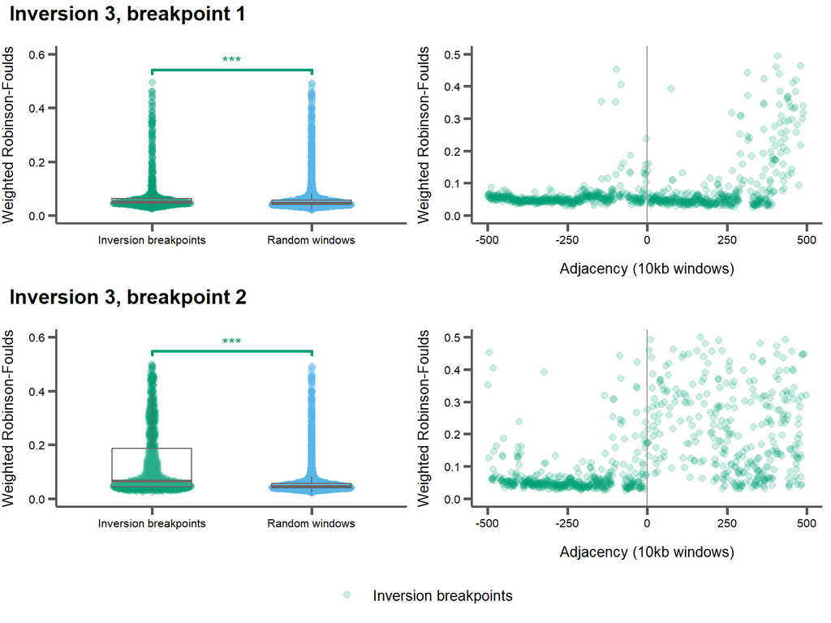

```r
inv_bp_windows = all_windows_f_overlaps %>% filter(inv.overlap == "inv03", inv.overlap.bp < 10000)
#tree1 = ggdraw() + draw_label("FILTERED")
#tree2 = plotBPTree(inv_bp_windows[1,], 0.16)
# Get the trees around both breakpoints

##########

inv_bp1_dists = inv_bp_dists %>% filter(bed.id == "inv03.bp01")
dists1 = rbind(inv_bp1_dists, rand_dists)
inv_bp1_plots = plotBPDists(dists1, yvar="wrf.st", color_pal="st")
# Get the distances and plots from bp1

inv_bp2_dists = inv_bp_dists %>% filter(bed.id == "inv03.bp02")
dists2 = rbind(inv_bp2_dists, rand_dists)
inv_bp2_plots = plotBPDists(dists2, yvar="wrf.st", color_pal="st")
# Get the distances and plots from bp2

#print(wrf_adj)

##########

leg = get_legend(inv_bp2_plots$wrf.adj)
title1 = ggdraw() +
  draw_label("Inversion 3, breakpoint 1",
             fontface="bold",
             x=0,
             hjust=0) +
  theme(plot.margin=margin(0,0,0,7))

title2 = ggdraw() +
  draw_label("Inversion 3, breakpoint 2",
             fontface="bold",
             x=0,
             hjust=0) +
  theme(plot.margin=margin(0,0,0,7))

p1_main = plot_grid(inv_bp1_plots$wrf.dist, inv_bp1_plots$wrf.adj + theme(legend.position="none"), ncol=2)
p1 = plot_grid(title1, p1_main, nrow=2, rel_heights=c(0.1,1))

p2_main = plot_grid(inv_bp2_plots$wrf.dist, inv_bp2_plots$wrf.adj + theme(legend.position="none"), ncol=2)
p2 = plot_grid(title2, p2_main, nrow=2, rel_heights=c(0.1,1))

p_main = plot_grid(p1, p2, nrow=2, label_size=14, align='vh')
p = plot_grid(p_main, leg, nrow=2, rel_heights=c(1,0.1))
print(p)
```

## 8.5 Inversion 4 breakpoints

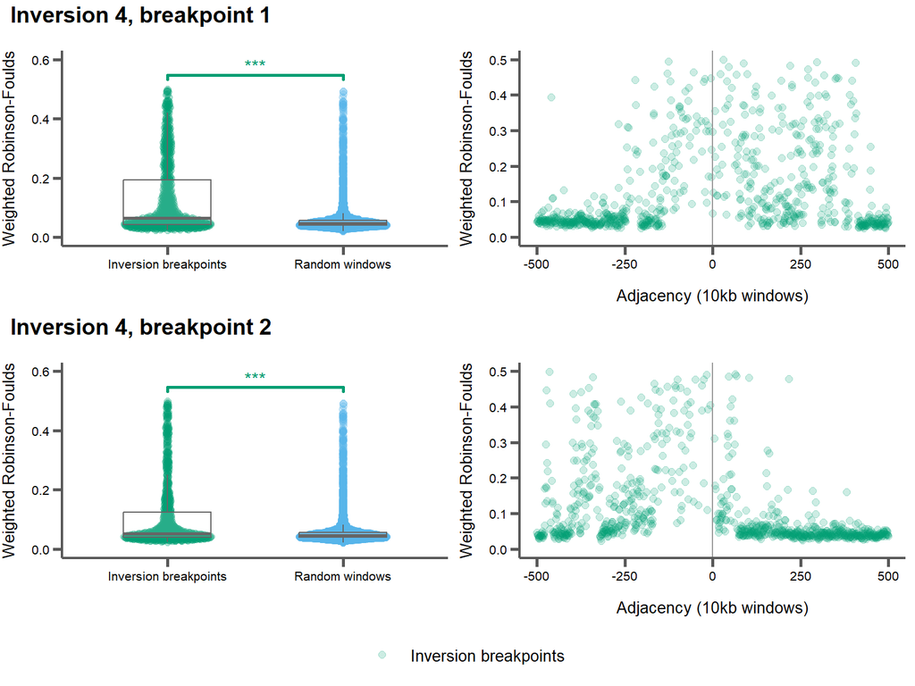

```r
inv_bp_windows = all_windows_f_overlaps %>% filter(inv.overlap == "inv04", inv.overlap.bp < 10000)
#tree1 = plotBPTree(inv_bp_windows[1,], 0.25)
#tree2 = ggdraw() + draw_label("FILTERED")
# Get the trees around both breakpoints

##########

inv_bp1_dists = inv_bp_dists %>% filter(bed.id == "inv04.bp01")
dists1 = rbind(inv_bp1_dists, rand_dists)
inv_bp1_plots = plotBPDists(dists1, yvar="wrf.st", color_pal="st")
# Get the distances and plots from bp1

inv_bp2_dists = inv_bp_dists %>% filter(bed.id == "inv04.bp02")
dists2 = rbind(inv_bp2_dists, rand_dists)
inv_bp2_plots = plotBPDists(dists2, yvar="wrf.st", color_pal="st")
# Get the distances and plots from bp2

#print(wrf_adj)

##########

leg = get_legend(inv_bp1_plots$wrf.adj)
title1 = ggdraw() +
  draw_label("Inversion 4, breakpoint 1",
             fontface="bold",
             x=0,
             hjust=0) +
  theme(plot.margin=margin(0,0,0,7))

title2 = ggdraw() +
  draw_label("Inversion 4, breakpoint 2",
             fontface="bold",
             x=0,
             hjust=0) +
  theme(plot.margin=margin(0,0,0,7))

p1_main = plot_grid(inv_bp1_plots$wrf.dist, inv_bp1_plots$wrf.adj + theme(legend.position="none"), ncol=2)
p1 = plot_grid(title1, p1_main, nrow=2, rel_heights=c(0.1,1))

p2_main = plot_grid(inv_bp2_plots$wrf.dist, inv_bp2_plots$wrf.adj + theme(legend.position="none"), ncol=2)
p2 = plot_grid(title2, p2_main, nrow=2, rel_heights=c(0.1,1))

p_main = plot_grid(p1, p2, nrow=2, label_size=14, align='vh')
p = plot_grid(p_main, leg, nrow=2, rel_heights=c(1,0.1))
print(p)
```